# INTRODUCTION:

# Mannwhitneyu Test

H0:the pop median_status_joined=the pop median_status_not joined.

H1:the pop median_status_joined=!the pop median_status_not joined.

```python
#non parametirc test:
st.mannwhitneyu(a,b)
```

```
MannwhitneyuResult(statistic=4578698.5, pvalue=1.5757624735955582e-74)
```

since p(1.5757624735955582e-74)value reject H0 hence we can conclude that the pop median of status are not equal for joined and not joined. so notice period influnce by the candidate joined or not joined.

4.To verify Location and Status.

```python
df = pd.read_csv(r"C:\Users\User\Desktop\HRData.csv")
df
```

|  | Unnamed: 0 | Sno | Candidate_Ref | DOJ_Extended | Duration_to_accept_offer | Notice_Period | Offered_Band | Percent_hike_expected_in_CTC | Percent_hike_offered_in_CTC | Percent_difference_CTC | ... | Candidate_Source | Rex_in_Yrs | Postal_Code | Age | Domicile_Name | Date_of_Interview | Status | LOB | Location | Region_Name |
| --- | --- | --- | --- | --- | --- | --- | --- | --- | --- | --- | --- | --- | --- | --- | --- | --- | --- | --- | --- | --- | --- |
| 0 | 0 | 1 | 2110407 | Yes | 14 | 30 | E2 | -20.79 | 13.16 | 42.86 | ... | Agency | 7 | 201301 | 34.0 | Goa | 08-01-2013 | Joined | ERS | Noida | North |
| 1 | 1 | 195 | 2605197 | No | 1 | 60 | E1 | 40.35 | 31.58 | -6.25 | ... | Employee Referral | 1 | 201301 | 25.0 | Goa | 17-04-2013 | Joined | ERS | Noida | North |
| 2 | 2 | 588 | 2127782 | No | 17 | 30 | E3 | 20.00 | 20.00 | 0.00 | ... | Direct | 10 | 201301 | 36.0 | Goa | 20-05-2014 | Joined | ERS | Noida | North |
| 3 | 3 | 632 | 2138445 | No | 2 | 30 | E1 | 132.45 | 42.86 | -38.54 | ... | Direct | 4 | 201301 | 30.0 | Goa | 29-06-2014 | Joined | ERS | Noida | North |
| 4 | 4 | 688 | 2150946 | Yes | 4 | 30 | E1 | 22.22 | -23.33 | -37.27 | ... | Agency | 2 | 201301 | 26.0 | Goa | 11-04-2014 | Joined | ERS | Noida | North |
| ... | ... | ... | ... | ... | ... | ... | ... | ... | ... | ... | ... | ... | ... | ... | ... | ... | ... | ... | ... | ... | ... |
| 8990 | 8990 | 10033 | 3393127 | No | 1 | 0 | E1 | 42.86 | 42.86 | 0.00 | ... | Employee Referral | 2 | 382460 | 34.0 | Kerala | 01-07-2014 | Joined | INFRA | NaN | NaN |
| 8991 | 8991 | 3893 | 2419919 | Yes | 20 | 30 | E1 | 6.48 | 6.48 | 0.00 | ... | Direct | 5 | 411006 | 31.0 | Haryana | 25-10-2013 | Joined | INFRA | NaN | NaN |
| 8992 | 8992 | 8977 | 3304772 | Yes | 0 | 30 | E1 | 48.15 | 57.41 | 6.25 | ... | Employee Referral | 2 | 400001 | 27.0 | Haryana | 22-12-2013 | Joined | INFRA | NaN | NaN |
| 8993 | 8993 | 11222 | 3544858 | No | 13 | 30 | E1 | 67.08 | 42.86 | -14.50 | ... | Direct | 4 | 700027 | 34.0 | Punjab | 26-05-2013 | Joined | INFRA | NaN | NaN |
| 8994 | 8994 | 594 | 2128714 | Yes | 41 | 45 | E1 | 20.00 | 4.00 | -13.33 | ... | Direct | 5 | 560002 | 33.0 | Bihar | 24-05-2014 | Joined | AXON | NaN | NaN |

8995 rows × 23 columns

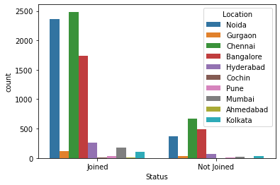

```python
sns.countplot(x='Status',hue='Location',data=df)
plt.show()
```

# CHI-SQUARE TEST

```python
df=pd.crosstab(df.Location,df.Status)
df
```

| Status Location | Joined | Not Joined |
| --- | --- | --- |
| Ahmedabad | 5 | 1 |
| Bangalore | 1742 | 488 |
| Chennai | 2486 | 664 |
| Cochin | 7 | 1 |
| Gurgaon | 118 | 28 |
| Hyderabad | 266 | 75 |
| Kolkata | 100 | 29 |
| Mumbai | 176 | 21 |
| Noida | 2362 | 365 |
| Pune | 38 | 10 |

H0: There is no association b/w Location and Status

H1: There is an association b/w Location and Status

```python
st.chi2_contingency(df)
```

```
(89.57817807505138,
 1.978307585717949e-15,
 9,
 array([[4.87641951e+00, 1.12358049e+00],
        [1.81240258e+03, 4.17597417e+02],
        [2.56012024e+03, 5.89879760e+02],
        [6.50189267e+00, 1.49810733e+00],
        [1.18659541e+02, 2.73404587e+01],
        [2.77143175e+02, 6.38568248e+01],
        [1.04843019e+02, 2.41569806e+01],
        [1.60109107e+02, 3.68908929e+01],
        [2.21633267e+03, 5.10667335e+02],
        [3.90113560e+01, 8.98864395e+00]]))
```

```python
#pvalue
st.chi2.sf(89.57817807505138,9)
```

```
1.978307585717949e-15
```

```python
# chi square critical value
st.chi2.isf(0.05,9)
```

```
16.91897760462045
```

p value(1.978307585717949e-15) < alpha(0.05)-->reject the H0 We conclude that There is an association b/w Location and Status.

5.To verify Duration_to_accept_offer and Status impact the candidate joined or not joined.

```python
a= df[df.Status=='Joined']['Duration_to_accept_offer']
b= df[df.Status=='Not Joined']['Duration_to_accept_offer']
```

```python
# normality test:
st.shapiro(a)
```

```
ShapiroResult(statistic=0.8031497001647949, pvalue=0.0)
```

```python
st.levene(a,b)
```

```
LeveneResult(statistic=32.56020341340111, pvalue=1.1921738123609167e-08)
```

INFERENCE: p value is < alpha so fail to normalitiy test.

# Mannwhitneyu Test

H0:the population median of Duration_to_accept_offer is = population median of Status H1:the population median of Duration_to_accept_offer is! = population median of Status

```python
# use to non parametric test:
st.mannwhitneyu(a,b)
```

```
MannwhitneyuResult(statistic=5637836.0, pvalue=9.192784994227073e-08)
```

INFERENCE: since p(9.192784994227073e-08) valuereject H0 hence we can conclude that the population median of Duration_to_accept_offer is not equal to population median of Status.

# TASK 1.3 (Exploratory Data Analysis)

Data Preparation/Analysis tasks including (but not limited to) the following. ● Univariate, Bi- Variate Analysis and Multi- Variate Analysis ● Missing values identification and treatment ● Outlier analysis and treatment ● Data scaling using min-max and/or Z-score normalisation ● Data transformation ● Feature Engineering

```python
import matplotlib.pyplot as plt
import seaborn as sns
```

```python
df = pd.read_csv(r"C:\Users\User\Desktop\HRData.csv")
df
```

|  | Unnamed: 0 | Sno | Candidate_Ref | DOJ_Extended | Duration_to_accept_offer | Notice_Period | Offered_Band | Percent_hike_expected_in_CTC | Percent_hike_offered_in_CTC | Percent_difference_CTC | ... | Candidate_Source | Rex_in_Yrs | Postal_Code | Age | Domicile_Name | Date_of_Interview | Status | LOB | Location | Region_Name |
| --- | --- | --- | --- | --- | --- | --- | --- | --- | --- | --- | --- | --- | --- | --- | --- | --- | --- | --- | --- | --- | --- |
| 0 | 0 | 1 | 2110407 | Yes | 14 | 30 | E2 | -20.79 | 13.16 | 42.86 | ... | Agency | 7 | 201301 | 34.0 | Goa | 08-01-2013 | Joined | ERS | Noida | North |
| 1 | 1 | 195 | 2605197 | No | 1 | 60 | E1 | 40.35 | 31.58 | -6.25 | ... | Employee Referral | 1 | 201301 | 25.0 | Goa | 17-04-2013 | Joined | ERS | Noida | North |
| 2 | 2 | 588 | 2127782 | No | 17 | 30 | E3 | 20.00 | 20.00 | 0.00 | ... | Direct | 10 | 201301 | 36.0 | Goa | 20-05-2014 | Joined | ERS | Noida | North |
| 3 | 3 | 632 | 2138445 | No | 2 | 30 | E1 | 132.45 | 42.86 | -38.54 | ... | Direct | 4 | 201301 | 30.0 | Goa | 29-06-2014 | Joined | ERS | Noida | North |
| 4 | 4 | 688 | 2150946 | Yes | 4 | 30 | E1 | 22.22 | -23.33 | -37.27 | ... | Agency | 2 | 201301 | 26.0 | Goa | 11-04-2014 | Joined | ERS | Noida | North |
| ... | ... | ... | ... | ... | ... | ... | ... | ... | ... | ... | ... | ... | ... | ... | ... | ... | ... | ... | ... | ... | ... |
| 8990 | 8990 | 10033 | 3393127 | No | 1 | 0 | E1 | 42.86 | 42.86 | 0.00 | ... | Employee Referral | 2 | 382460 | 34.0 | Kerala | 01-07-2014 | Joined | INFRA | NaN | NaN |
| 8991 | 8991 | 3893 | 2419919 | Yes | 20 | 30 | E1 | 6.48 | 6.48 | 0.00 | ... | Direct | 5 | 411006 | 31.0 | Haryana | 25-10-2013 | Joined | INFRA | NaN | NaN |
| 8992 | 8992 | 8977 | 3304772 | Yes | 0 | 30 | E1 | 48.15 | 57.41 | 6.25 | ... | Employee Referral | 2 | 400001 | 27.0 | Haryana | 22-12-2013 | Joined | INFRA | NaN | NaN |
| 8993 | 8993 | 11222 | 3544858 | No | 13 | 30 | E1 | 67.08 | 42.86 | -14.50 | ... | Direct | 4 | 700027 | 34.0 | Punjab | 26-05-2013 | Joined | INFRA | NaN | NaN |
| 8994 | 8994 | 594 | 2128714 | Yes | 41 | 45 | E1 | 20.00 | 4.00 | -13.33 | ... | Direct | 5 | 560002 | 33.0 | Bihar | 24-05-2014 | Joined | AXON | NaN | NaN |

8995 rows × 23 columns

# UNIVARIATE ANALYSIS:

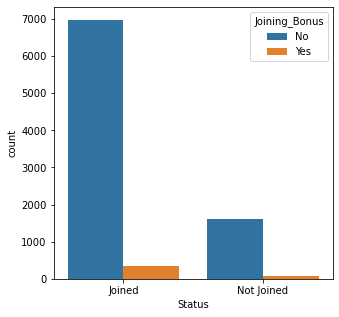

```python
plt.figure(figsize = (5,5))
sns.countplot(x='Status',hue='Joining_Bonus',data=df)
plt.show()
```

INSIGHTS: Most of the candidates not expected joining bonus.

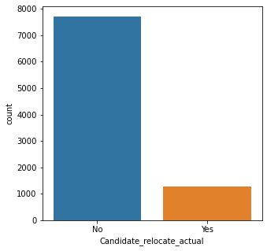

```python
plt.figure(figsize = (5,5))
sns.countplot(x='Candidate_relocate_actual',data=df)
plt.show()
```

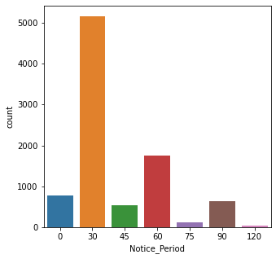

```python
plt.figure(figsize = (5,5))
sns.countplot(x='Notice_Period',data=df)
plt.show()
```

INSIGHTS: Mostly candidates 30 days asking notice period.

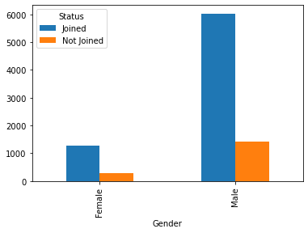

```python
pd.crosstab(df['Gender'],df['Status']).plot(kind='bar')
plt.figure(figsize=(15,15))
```

INSIGHTS: Most of the candidates joined male.

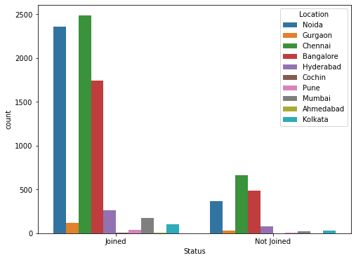

```python
plt.figure(figsize = (8,6))
sns.countplot(x='Status',hue='Location',data=df)
plt.show()
```

# BIVARIATE

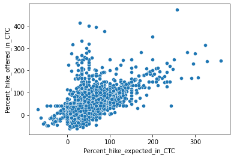

```python
sns.scatterplot(x='Percent_hike_expected_in_CTC',y='Percent_hike_offered_in_CTC',data=df)
```

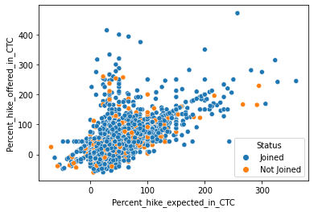

```python
sns.scatterplot(x='Percent_hike_expected_in_CTC',y='Percent_hike_offered_in_CTC',hue='Status',data=df)
```

INFERNCE: Most of the candidate not expected Percent_hike_expected_in_CTC.

```python
corr_matrix=df.corr()
```

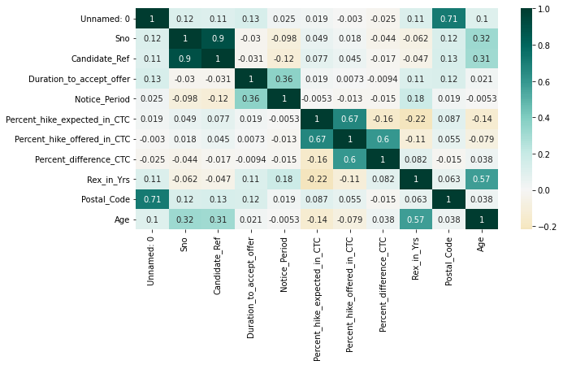

```python
plt.figure(1,figsize=(10,5))
sns.heatmap(corr_matrix,cmap='BrBG',center=0,annot=True)
```

# MULTIVARTAITE ANAYLIS

```python
numerical_features=['Duration_to_accept_offer','Notice_Period','Percent_hike_expected_in_CTC','Percent_difference_CTC','Rex_in_Yrs','Age']
```

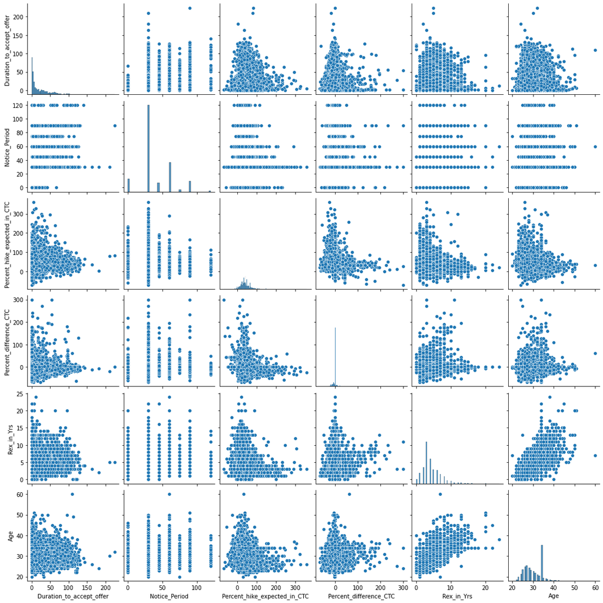

```python
sns.pairplot(df[numerical_features],data=df)
```

# OUTLIER IDENTIFICATION:

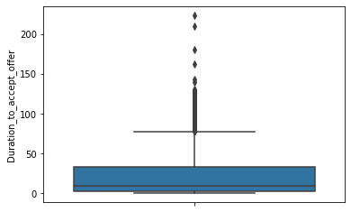

```python
sns.boxplot(y='Duration_to_accept_offer',data=df)
```

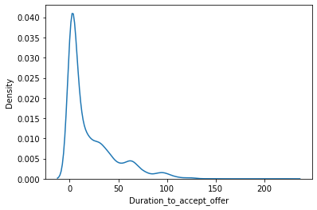

```python
sns.kdeplot(x='Duration_to_accept_offer',data=df)
```

INSIGHTS: This plot follwed by Right skewed.

# OUTLIER DETECTION:

```python
# IQR method for identifying outliers
df1=df.copy()
IQR  = df1['Duration_to_accept_offer'].quantile(0.75)- df1['Duration_to_accept_offer'].quantile(0.25)
upper = df1['Duration_to_accept_offer'].quantile(0.75) + (1.5*IQR)
lower = df1['Duration_to_accept_offer'].quantile(0.25) - (1.5*IQR)
df1[(df1['Duration_to_accept_offer']> upper) | (df1['Duration_to_accept_offer']<lower)].shape[0]
```

```
394
```

```python
# Capping outliers
max1=df1['Duration_to_accept_offer'].quantile(0.95)
min1=df1['Duration_to_accept_offer'].quantile(0.05)
df1['Duration_to_accept_offer']=np.clip(df1['Duration_to_accept_offer'],min1,max1)
```

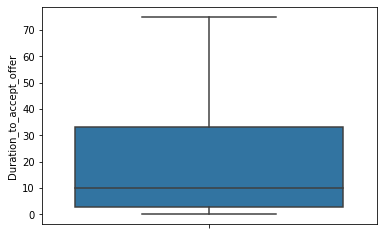

```python
sns.boxplot(y='Duration_to_accept_offer',data=df1)
```

# TRANSFORMATION

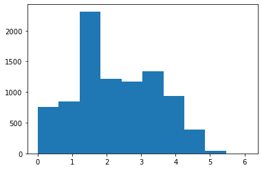

```python
df['Duration_to_accept_offer_cbrt'] = np.cbrt(df['Duration_to_accept_offer'])
plt.hist(df['Duration_to_accept_offer_cbrt'])
```

INSIGHTS: This plot is followed by normal distribution.

# OUTLIER IDENTIFICATION:

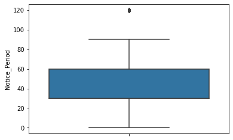

```python
sns.boxplot(y='Notice_Period',data=df)
```

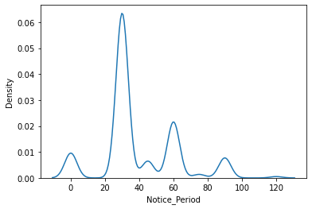

```python
sns.kdeplot(x='Notice_Period',data=df)
```

# OUTLIER DETECTION:

```python
# zscore method
df3=df1.copy()
upper=df3['Notice_Period'].mean()+(3*df3['Notice_Period'].std())
lower=df3['Notice_Period'].mean()-(3*df3['Notice_Period'].std())
df3[(df3['Notice_Period']>upper)|(df3['Notice_Period']<lower)].shape[0]
```

```
42
```

```python
# Capping outliers
max1=df3['Notice_Period'].quantile(0.95)
min1=df3['Notice_Period'].quantile(0.05)
df3['Notice_Period']=np.clip(df3['Notice_Period'],min1,max1)
```

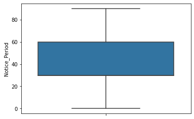

```python
sns.boxplot(y='Notice_Period',data=df3)
```

# TRANSFORMATION

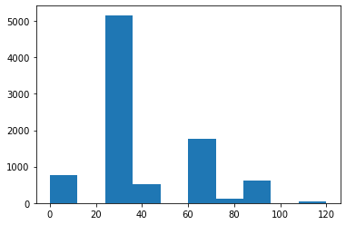

```python
df4=df1.copy()
df4['Notice_Period']=np.log(df4['Notice_Period'])
plt.hist(df1['Notice_Period'])
```

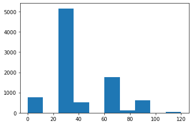

```python
df2['Notice_Period_log']=np.log(df2['Notice_Period'])
df2['Notice_Period_sqrt']=np.sqrt(df2['Notice_Period'])
plt.hist(df1['Notice_Period']);
```

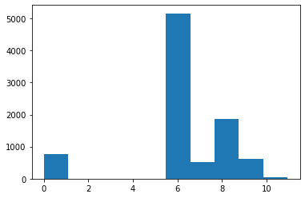

```python
plt.hist(df2['Notice_Period_sqrt'])
```

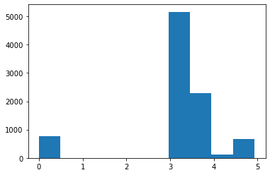

```python
df1['Notice_Period_cbrt'] = np.cbrt(df1['Notice_Period'])
plt.hist(df1['Notice_Period_cbrt'])
```

# OULIER IDENTIFICATION:

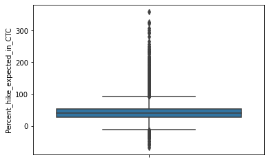

```python
sns.boxplot(y='Percent_hike_expected_in_CTC',data=df)
```

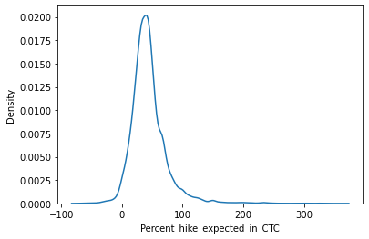

```python
sns.kdeplot(x='Percent_hike_expected_in_CTC',data=df)
```

INSIGHTS: This polt is approximately normal distribution.

# OUTLIER DETECTION:

```python
# zscore method
df3=df1.copy()
upper=df3['Percent_hike_expected_in_CTC'].mean()+(3*df3['Percent_hike_expected_in_CTC'].std())
lower=df3['Percent_hike_expected_in_CTC'].mean()-(3*df3['Percent_hike_expected_in_CTC'].std())
df3[(df3['Percent_hike_expected_in_CTC']>upper)|(df3['Percent_hike_expected_in_CTC']<lower)].shape[0]
```

```
144
```

```python
# Capping outliers
max1=df3['Percent_hike_expected_in_CTC'].quantile(0.90)
min1=df3['Percent_hike_expected_in_CTC'].quantile(0.10)
df3['Percent_hike_expected_in_CTC']=np.clip(df3['Percent_hike_expected_in_CTC'],min1,max1)
```

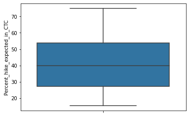

```python
sns.boxplot(y='Percent_hike_expected_in_CTC',data=df3)
```

# TRANSFORMATION

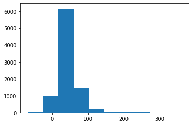

```python
df3['Percent_hike_expected_in_CTC_log']=np.log(df3['Percent_hike_expected_in_CTC'])
df3['Percent_hike_expected_in_CTC_sqrt']=np.sqrt(df3['Percent_hike_expected_in_CTC'])
plt.hist(df1['Percent_hike_expected_in_CTC']);
```

```python
INSIGHTS:
    This plot followed by normal distribution.
```

# OUTLIER IDENTIFICATION:

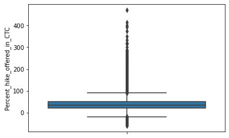

```python
sns.boxplot(y='Percent_hike_offered_in_CTC',data=df)
```

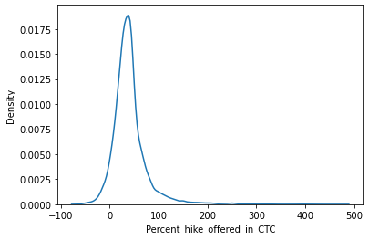

```python
sns.kdeplot(x='Percent_hike_offered_in_CTC',data=df)
```

INSIGHTS: Aprroximately normal distribution.

# OUTLIER DETECTION:

```python
# zscore method
df4=df1.copy()
upper=df4['Percent_hike_offered_in_CTC'].mean()+(3*df4['Percent_hike_offered_in_CTC'].std())
lower=df4['Percent_hike_offered_in_CTC'].mean()-(3*df4['Percent_hike_offered_in_CTC'].std())
df4[(df4['Percent_hike_offered_in_CTC']>upper)|(df4['Percent_hike_offered_in_CTC']<lower)].shape[0]
```

```
174
```

```python
# Capping outliers
max1=df4['Percent_hike_offered_in_CTC'].quantile(0.90)
min1=df4['Percent_hike_offered_in_CTC'].quantile(0.10)
df4['Percent_hike_offered_in_CTC']=np.clip(df4['Percent_hike_offered_in_CTC'],min1,max1)
```

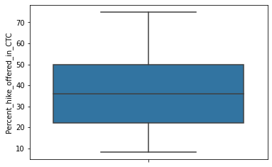

```python
sns.boxplot(y='Percent_hike_offered_in_CTC',data=df4)
```

# TRANSFOMATION

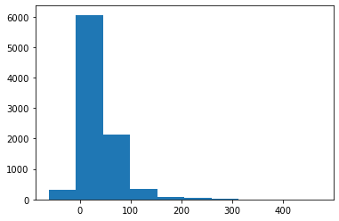

```python
df5=df1.copy()
df5['Percent_hike_offered_in_CTC']=np.log(df5['Percent_hike_offered_in_CTC'])
plt.hist(df1['Percent_hike_offered_in_CTC'])
```

# OUTLIER IDENTIFICATION:

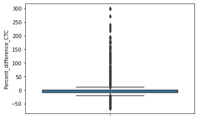

```python
sns.boxplot(y='Percent_difference_CTC',data=df)
```

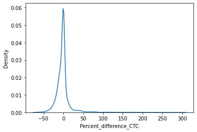

```python
sns.kdeplot(x='Percent_difference_CTC',data=df)
```

# OUTLIER DETECTION:

```python
# zscore method
df6=df1.copy()
upper=df6['Percent_difference_CTC'].mean()+(3*df6['Percent_difference_CTC'].std())
lower=df6['Percent_difference_CTC'].mean()-(3*df6['Percent_difference_CTC'].std())
df6[(df6['Percent_difference_CTC']>upper)|(df6['Percent_difference_CTC']<lower)].shape[0]
```

```
145
```

```python
# Capping outliers
max1=df6['Percent_difference_CTC'].quantile(0.90)
min1=df6['Percent_difference_CTC'].quantile(0.10)
df6['Percent_difference_CTC']=np.clip(df6['Percent_difference_CTC'],min1,max1)
```

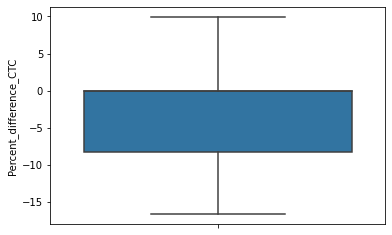

```python
sns.boxplot(y='Percent_difference_CTC',data=df6)
```

# TRANSFORMATION

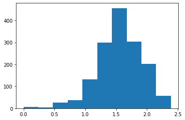

```python
plt.hist(df7['Percent_difference_CTC_sqrt'])
```

INSIGHTS: This plot is followed by approximately normal distribution.

# OURLIER IDENTIFICATION:

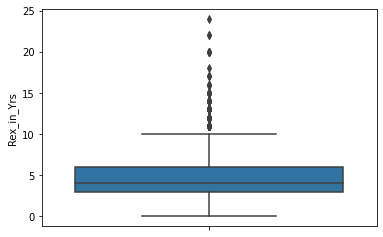

```python
sns.boxplot(y='Rex_in_Yrs',data=df)
```

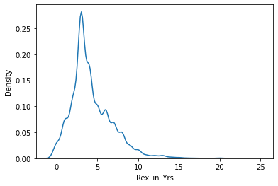

```python
sns.kdeplot(x='Rex_in_Yrs',data=df)
```

# OUTLIER DETECTION:

```python
# zscore method
df8=df1.copy()
upper=df8['Rex_in_Yrs'].mean()+(3*df8['Rex_in_Yrs'].std())
lower=df8['Rex_in_Yrs'].mean()-(3*df8['Rex_in_Yrs'].std())
df8[(df8['Rex_in_Yrs']>upper)|(df8['Rex_in_Yrs']<lower)].shape[0]
```

```
142
```

```python
# Capping outliers
max1=df8['Rex_in_Yrs'].quantile(0.95)
min1=df8['Rex_in_Yrs'].quantile(0.05)
df8['Rex_in_Yrs']=np.clip(df8['Rex_in_Yrs'],min1,max1)
```

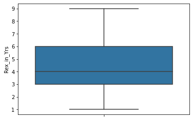

```python
sns.boxplot(y='Rex_in_Yrs',data=df8)
```

# TRANSFORMATION

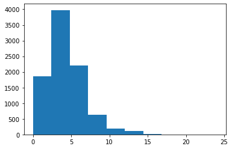

```python
df9=df1.copy()
df9['Rex_in_Yrs']=np.log(df9['Rex_in_Yrs'])
plt.hist(df1['Rex_in_Yrs'])
```

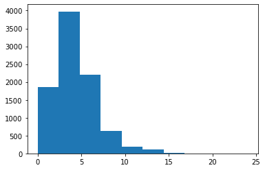

```python
df9['Rex_in_Yrs_log']=np.log(df9['Rex_in_Yrs'])
df9['Rex_in_Yrs_sqrt']=np.sqrt(df9['Rex_in_Yrs'])
plt.hist(df1['Rex_in_Yrs']);
```

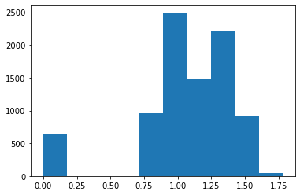

```python
plt.hist(df9['Rex_in_Yrs_sqrt'])
```

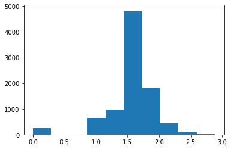

```python
df['Rex_in_Yrs_cbrt'] = np.cbrt(df['Rex_in_Yrs'])
plt.hist(df['Rex_in_Yrs_cbrt'])
```

# OUTLIER IDENTIFICATION:

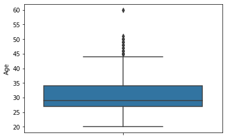

```python
sns.boxplot(y='Age',data=df)
```

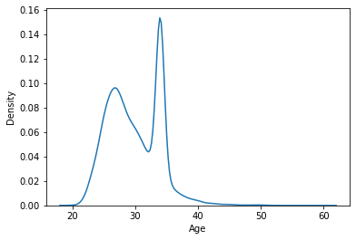

```python
sns.kdeplot(x='Age',data=df)
```

# OUTLIER DETECTION:

```python
# zscore method
df10=df1.copy()
upper=df10['Age'].mean()+(3*df10['Age'].std())
lower=df10['Age'].mean()-(3*df10['Age'].std())
df9[(df10['Age']>upper)|(df10['Age']<lower)].shape[0]
```

```
43
```

```python
# Capping outliers
max1=df10['Age'].quantile(0.95 )
min1=df10['Age'].quantile(0.01)
df10['Age']=np.clip(df10['Age'],min1,max1)
```

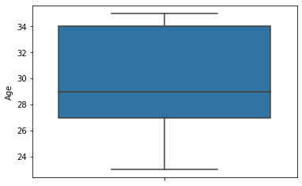

```python
sns.boxplot(y='Age',data=df10)
```

# TRANSFORMATION:

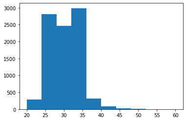

```python
df11=df1.copy()
df11['Age']=np.log(df11['Age'])
plt.hist(df1['Age'])
```

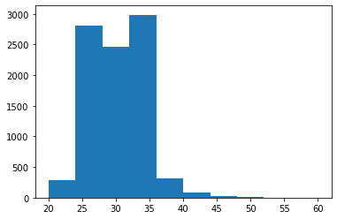

```python
df11['Age_log']=np.log(df11['Age'])
df11['Age_sqrt']=np.sqrt(df11['Age'])
plt.hist(df1['Age']);
```

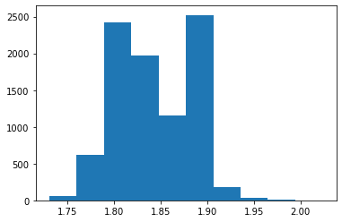

```python
plt.hist(df11['Age_sqrt'])
```

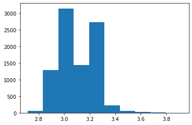

```python
df['Age_cbrt'] = np.cbrt(df['Age'])
plt.hist(df['Age_cbrt'])
```

# LABEL ENCODING

```python
from sklearn.preprocessing import LabelEncoder
```

```python
df12=df1.copy()
```

```python
le = LabelEncoder()
for i in ['DOJ_Extended','Offered_Band','Joining_Bonus','Candidate_relocate_actual','Gender','Candidate_Source','Domicile_Name','Date_of_Interview','Status','LOB','Location','Region_Name']:
    df12[i]=le.fit_transform(df12[i].values.reshape(-1,1))
```

```python
df12.head()
```

|  | Unnamed: 0 | Sno | Candidate_Ref | DOJ_Extended | Duration_to_accept_offer | Notice_Period | Offered_Band | Percent_hike_expected_in_CTC | Percent_hike_offered_in_CTC | Percent_difference_CTC | ... | Candidate_Source | Rex_in_Yrs | Postal_Code | Age | Domicile_Name | Date_of_Interview | Status | LOB | Location | Region_Name |
| --- | --- | --- | --- | --- | --- | --- | --- | --- | --- | --- | --- | --- | --- | --- | --- | --- | --- | --- | --- | --- | --- |
| 0 | 0 | 1 | 2110407 | 1 | 14.0 | 30 | 2 | -20.79 | 13.16 | 42.86 | ... | 0 | 7 | 201301 | 34.0 | 5 | 110 | 0 | 4 | 8 | 1 |
| 1 | 1 | 195 | 2605197 | 0 | 1.0 | 60 | 1 | 40.35 | 31.58 | -6.25 | ... | 2 | 1 | 201301 | 25.0 | 5 | 266 | 0 | 4 | 8 | 1 |
| 2 | 2 | 588 | 2127782 | 0 | 17.0 | 30 | 3 | 20.00 | 20.00 | 0.00 | ... | 1 | 10 | 201301 | 36.0 | 5 | 318 | 0 | 4 | 8 | 1 |
| 3 | 3 | 632 | 2138445 | 0 | 2.0 | 30 | 1 | 132.45 | 42.86 | -38.54 | ... | 1 | 4 | 201301 | 30.0 | 5 | 467 | 0 | 4 | 8 | 1 |
| 4 | 4 | 688 | 2150946 | 1 | 4.0 | 30 | 1 | 22.22 | -23.33 | -37.27 | ... | 0 | 2 | 201301 | 26.0 | 5 | 169 | 0 | 4 | 8 | 1 |

5 rows × 23 columns

# Scaler

```python
from sklearn.preprocessing import MinMaxScaler,StandardScaler,RobustScaler
```

```python
df13=df12.copy()
```

```python
minmax= MinMaxScaler()
for i in df13.columns:
    df13[i]=minmax.fit_transform(df13[i].values.reshape(-1,1))
df13
```

|  | Unnamed: 0 | Sno | Candidate_Ref | DOJ_Extended | Duration_to_accept_offer | Notice_Period | Offered_Band | Percent_hike_expected_in_CTC | Percent_hike_offered_in_CTC | Percent_difference_CTC | ... | Candidate_Source | Rex_in_Yrs | Postal_Code | Age | Domicile_Name | Date_of_Interview | Status | LOB | Location | Region_Name |
| --- | --- | --- | --- | --- | --- | --- | --- | --- | --- | --- | --- | --- | --- | --- | --- | --- | --- | --- | --- | --- | --- |
| 0 | 0.000000 | 0.000000 | 0.000476 | 1.0 | 0.186667 | 0.250 | 0.50 | 0.112086 | 0.138525 | 0.299861 | ... | 0.0 | 0.291667 | 0.137033 | 0.350 | 0.217391 | 0.220884 | 0.0 | 0.500 | 0.8 | 0.25 |
| 1 | 0.000111 | 0.015731 | 0.287063 | 0.0 | 0.013333 | 0.500 | 0.25 | 0.254736 | 0.173152 | 0.166145 | ... | 1.0 | 0.041667 | 0.137033 | 0.125 | 0.217391 | 0.534137 | 0.0 | 0.500 | 0.8 | 0.25 |
| 2 | 0.000222 | 0.047600 | 0.010539 | 0.0 | 0.226667 | 0.250 | 0.75 | 0.207256 | 0.151384 | 0.183162 | ... | 0.5 | 0.416667 | 0.137033 | 0.400 | 0.217391 | 0.638554 | 0.0 | 0.500 | 0.8 | 0.25 |
| 3 | 0.000334 | 0.051168 | 0.016715 | 0.0 | 0.026667 | 0.250 | 0.25 | 0.469622 | 0.194357 | 0.078226 | ... | 0.5 | 0.166667 | 0.137033 | 0.250 | 0.217391 | 0.937751 | 0.0 | 0.500 | 0.8 | 0.25 |
| 4 | 0.000445 | 0.055709 | 0.023956 | 1.0 | 0.053333 | 0.250 | 0.25 | 0.212436 | 0.069930 | 0.081684 | ... | 0.0 | 0.083333 | 0.137033 | 0.150 | 0.217391 | 0.339357 | 0.0 | 0.500 | 0.8 | 0.25 |
| ... | ... | ... | ... | ... | ... | ... | ... | ... | ... | ... | ... | ... | ... | ... | ... | ... | ... | ... | ... | ... | ... |
| 8990 | 0.999555 | 0.813493 | 0.743440 | 0.0 | 0.013333 | 0.000 | 0.25 | 0.260593 | 0.194357 | 0.183162 | ... | 1.0 | 0.083333 | 0.450500 | 0.350 | 0.478261 | 0.018072 | 0.0 | 0.875 | 1.0 | 1.00 |
| 8991 | 0.999666 | 0.315602 | 0.179748 | 1.0 | 0.266667 | 0.250 | 0.25 | 0.175712 | 0.125968 | 0.183162 | ... | 0.5 | 0.208333 | 0.499894 | 0.275 | 0.304348 | 0.817269 | 0.0 | 0.875 | 1.0 | 1.00 |
| 8992 | 0.999778 | 0.727862 | 0.692263 | 1.0 | 0.000000 | 0.250 | 0.25 | 0.272935 | 0.221708 | 0.200180 | ... | 1.0 | 0.083333 | 0.480852 | 0.175 | 0.304348 | 0.716867 | 0.0 | 0.875 | 1.0 | 1.00 |
| 8993 | 0.999889 | 0.909909 | 0.831324 | 0.0 | 0.173333 | 0.250 | 0.25 | 0.317102 | 0.194357 | 0.143682 | ... | 0.5 | 0.166667 | 1.000000 | 0.350 | 0.695652 | 0.833333 | 0.0 | 0.875 | 1.0 | 1.00 |
| 8994 | 1.000000 | 0.048086 | 0.011079 | 1.0 | 0.546667 | 0.375 | 0.25 | 0.207256 | 0.121306 | 0.146867 | ... | 0.5 | 0.208333 | 0.757709 | 0.325 | 0.043478 | 0.769076 | 0.0 | 0.000 | 1.0 | 1.00 |

8995 rows × 23 columns

OVERALL INFERENCE: From the above test we conclude that the Candidate joined and not joined of is affected by the following factors

```
Joining_Bonus impact candidate joined and not joined.

Candidate_relocate_actual influnce by the status.so candidate relocate affected factors.

Duration_to_accept_offer impact the factors.

Gender provide insights into the company's diversity and inclusion initiatives.

percent_hike_expected_in_ctc the salaery expectations of the candidates and can  provide insights into the company's compensation.

percent_differnce_expected_in_ctc compare the expected ctc with the actual ctc offerd and can provide indights into the company structure.

DOJ_Extended the offer being extended by the company and can provide insights into the company's retention strategies.
```